# MCMC

# 1 Settings

The chapter contains some chunks that conduct document settings.

- This chunk **removes all the variables** in the environment.

```r
rm(list = ls(all = TRUE))
```

- This chunk **sets** `knitr` **options**.

```r
knitr::opts_chunk$set(
  block.title = TRUE,
  fig.align = "center",
  results = "hold",
  fig.show = "hold",
  message = FALSE,
  warning = FALSE,
  class.source = 'fold-hide'
)
knitr::opts_hooks$set(label = function(options) {
  options$before = paste0('<div>Chunk: ', options$label, '</div>')
  return(options)
})
```

- This chunk **loads the required packages** and **my functions**.

```r
pkgList <- c(
  "tidyverse", #must-have
  "purrr"
)
easypackages::libraries(pkgList)
rm(pkgList)
```

- This chunk sets **the seed**.

```r
set.seed(1111)
```

# 2 準備：マルコフ連鎖

マルコフ連鎖の条件（chap. 3）

$n$個の変数$\{x\}=x_1, x_2, \dots, x_n$を用いて確率$P(\{x\})$を与える

$\{x\}^{(k)}$から$\{x\}^{(k+1)}$が得られる確率「遷移確率」を、$T(\{x\}^{(k)} \rightarrow \{x\}^{(k+1)})$とかく。この時、以下の4つが満たされていること。

1. マルコフ性

$T(\{x\}^{(k)} \rightarrow \{x\}^{(k+1)})$が、それ以前の履歴（$\{x^{(1)}\}, \{x^{(2)}\}, \dots \{x^{(k-1)}\})$に依存しない…明らか

2. 既約性

あらゆる変数の組は、有限回のステップで移りあうことが可能→明らか

3. 非周期性

ステップ数 $n_s$ で$\{x\}$から$\{x'\}$に戻ってこれ、その最大公約数が$1$→明らか

4. 詳細釣り合い条件

$P(\{x\}) \cdot T(\{x\} \rightarrow \{x'\})=P(\{x'\}) \cdot T(\{x'\} \rightarrow \{x\})$

# 3 メトロポリス法

$$P(x) = \frac{e^{-S(x)}}{Z} \qquad \text{(4.1)}$$

e.g. ガウス積分：

$$P(x) = \frac{e^{\frac{x^2}{2}}}{\sqrt{2\pi}}$$

メトロポリス法 アルゴリズム

1. $\Delta x$をランダムに選び、$x' = x^{(k)} + \Delta x$を$x^{(k+1)}$の候補とする。
2. 一様乱数 $r \in (0,1)$を発生させる。
3. $e^{S(x^{(k)})-S(x')}>r$、i.e. 候補$x'$の方が現行の$x^{(k)}$より”ある程度”望ましければ、提案を受理して $x^{(k+1)}=x'$とする。さもなくば、提案を棄却して$x^{(k+1)}=x^{(k)}$とする。

なぜこの連鎖が詳細釣り合い条件を満たす？

$$\begin{aligned}
T(x \rightarrow x') &= \frac{1}{2c} \times \min (1,
e^{S(x)-S(x')}),\\
T(x' \rightarrow x) &= \frac{1}{2c} \times \min (1,
e^{S(x')-S(x)})
\end{aligned}$$

$S(x)-S(x')>0$のとき、
$$\begin{aligned}
P(x) \cdot T(x \rightarrow x') &= \frac{e^{-S(x)}}{Z} \times
\frac{1}{2c}\times 1\\
P(x') \cdot T(x' \rightarrow x) &= \frac{e^{-S(x')}}{Z}
\times \frac{1}{2c}\times e^{S(x')-S(x)} = \frac{e^{-S(x)}}{Z}
\times \frac{1}{2c}\times 1
\end{aligned}$$
$S(x)-S(x')<0$のときも同様。

## 3.1 数値例

```r
Sfun <- function(x){x^2/2}
```

初期値を$x_0=0$、stepを$\Delta x \sim U(-1,1)$ としたときのアルゴリズムは以下の通り。

```r
x_0 <- 0
step <- 1
n_smpl <- 10000

x_smpl <- numeric(n_smpl)
acc_smpl <- logical(n_smpl)

for (i in c(1:n_smpl)){
  ### current x ###
  if(i == 1){
    x_current <- x_0
  } else{
    x_current <- x_smpl[[i-1]]
  }
  ### proposed x ###
  x_prime <- x_current + runif(1, min = -step, max = step)

  ### probability ###
  prob <- min(1, exp(Sfun(x_current)-Sfun(x_prime)))

  ### accept or reject ###
  if(prob > runif(1, min = 0, max = 1)){
    x_smpl[[i]] <- x_prime
    acc_smpl[[i]] <- TRUE
  } else{
    x_smpl[[i]] <- x_current
    acc_smpl[[i]] <- FALSE
  }
}
```

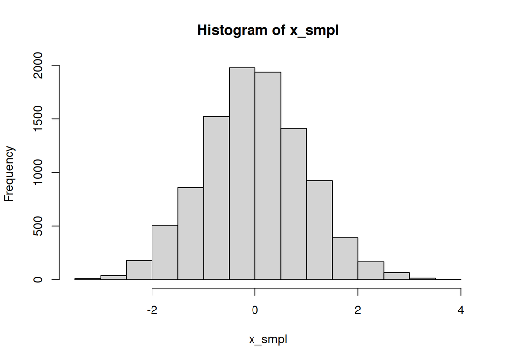

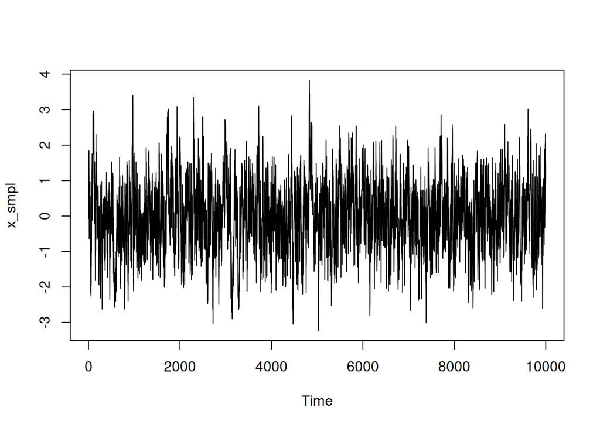

```r
hist(x_smpl)
ts.plot(x_smpl)
```

### 3.1.1 異なる設定

`run_metropolis` を定義して、複数の設定で走らせる。

```r
run_metropolis <- function(
  n_smpl,
  x_0 = 0,
  fun_proposal = function() runif(1, min = -1, max = 1)
){
  # safety checks
  if (!is.numeric(n_smpl) || length(n_smpl) != 1 || n_smpl < 1) {stop("n_smpl must be a positive scalar.")}
  n_smpl <- as.integer(n_smpl)
  if (!exists("Sfun", mode = "function", inherits = TRUE)) {stop("Sfun is not found. ")
  }

  # storage
  x_smpl <- numeric(n_smpl)
  acc <- logical(n_smpl)  # acceptance for each proposed move (length n_smpl)

  # Metropolis random-walk (proposal increment = fun_proposal())
  for (i in 1:n_smpl) {
    # current x
    if(i == 1){
      x_current <- x_0
    }else{
      x_current <- x_smpl[i-1]
    }

    # proposed x
    x_prime   <- x_current + fun_proposal()

    # probability
    prob <- min(1, exp(Sfun(x_current) - Sfun(x_prime)))

    # accept or reject
    if (prob > runif(1, 0, 1)) {
      x_smpl[i] <- x_prime
      acc[i] <- TRUE
    } else {
      x_smpl[i] <- x_current
      acc[i] <- FALSE
    }
  }

  list(
    x = x_smpl,                      # length n_smpl
    accept = acc,                    # length n_smpl
    accept_rate = mean(acc)
  )
}
```

```r
smpl_base <- list(x = x_smpl, accept = acc_smpl)
smpl_wide <- run_metropolis(n_smpl, x_0 = x_0, fun_proposal = function() runif(1, min = -50, max = 50))
smpl_narrow <- run_metropolis(n_smpl, x_0 = x_0, fun_proposal = function() runif(1, min = -0.3, max = 0.3))
smpl_far <- run_metropolis(n_smpl, x_0 = 10)
```

```r
chains <- list(
  baseline = smpl_base,
  wide     = smpl_wide,
  narrow   = smpl_narrow,
  far      = smpl_far
)

df_long <- imap_dfr(
  chains,
  ~ tibble(
      t = 1:length(.x$x),
      chain = .y,
      x = .x$x,
      accept = .x$accept
    )
)

df_long <- df_long %>%
  group_by(chain) %>%
  mutate(
    cummean = cummean(x),
    cumacc  = cumsum(accept) / t
  ) %>%
  ungroup()
```

**Trace plot**

- narrow は1回の移動距離が小さく、wideは同じ値が繰り返される →異なるメカニズムで**自己相関が高くなる**
- 初期値の影響は早々に消え去る

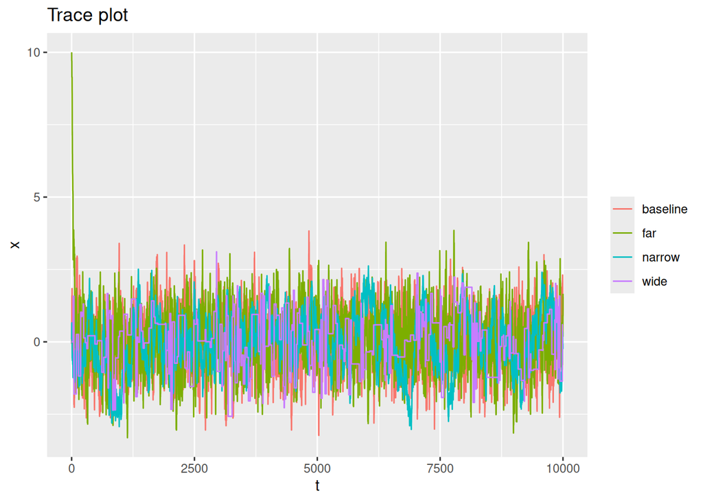

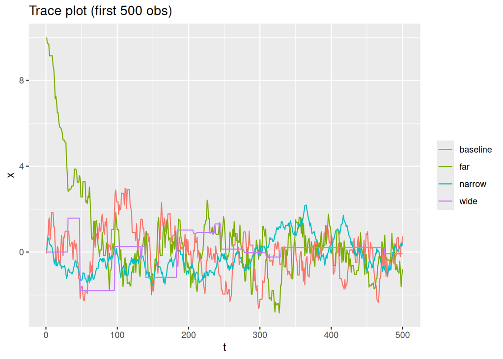

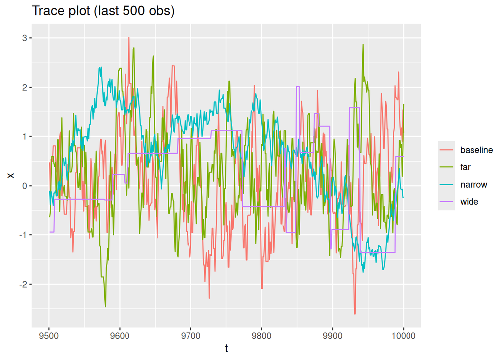

```r
df_long %>%
  ggplot(aes(x = t, y = x, color = chain)) +
  geom_line() +
  labs(title = "Trace plot", x = "t", y = "x", color = NULL)

# trace plot (first 500 obs)
df_long %>%
  filter(t<=500) %>%
  ggplot(aes(x = t, y = x, color = chain)) +
  geom_line() +
  labs(title = "Trace plot (first 500 obs)", x = "t", y = "x", color = NULL)

# trace plot (last 500 obs)
df_long %>%
  filter(t>n_smpl-500) %>%
  ggplot(aes(x = t, y = x, color = chain)) +
  geom_line() +
  labs(title = "Trace plot (last 500 obs)", x = "t", y = "x", color = NULL)
```

**acceptance ratio**

narrowは極端に高く、wideは低い。baseline、farはその中間（やや高め）

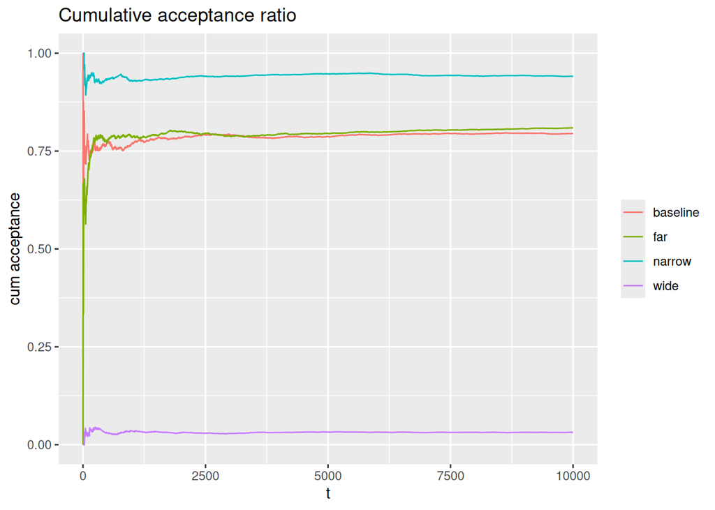

```r
# cum acceptance
df_long %>%
  ggplot(aes(x = t, y = cumacc, color = chain)) +
  geom_line() +
  labs(title = "Cumulative acceptance ratio", x = "t", y = "cum acceptance", color = NULL)
```

**累積平均・分布**

- 累積平均は、narrow、wideで時間がかかりつつも、10000サンプルでは概ね0に収束
- 分布も、narrow、wideは形が変

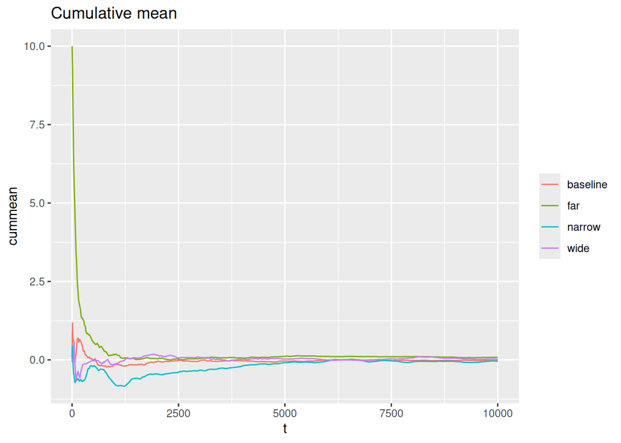

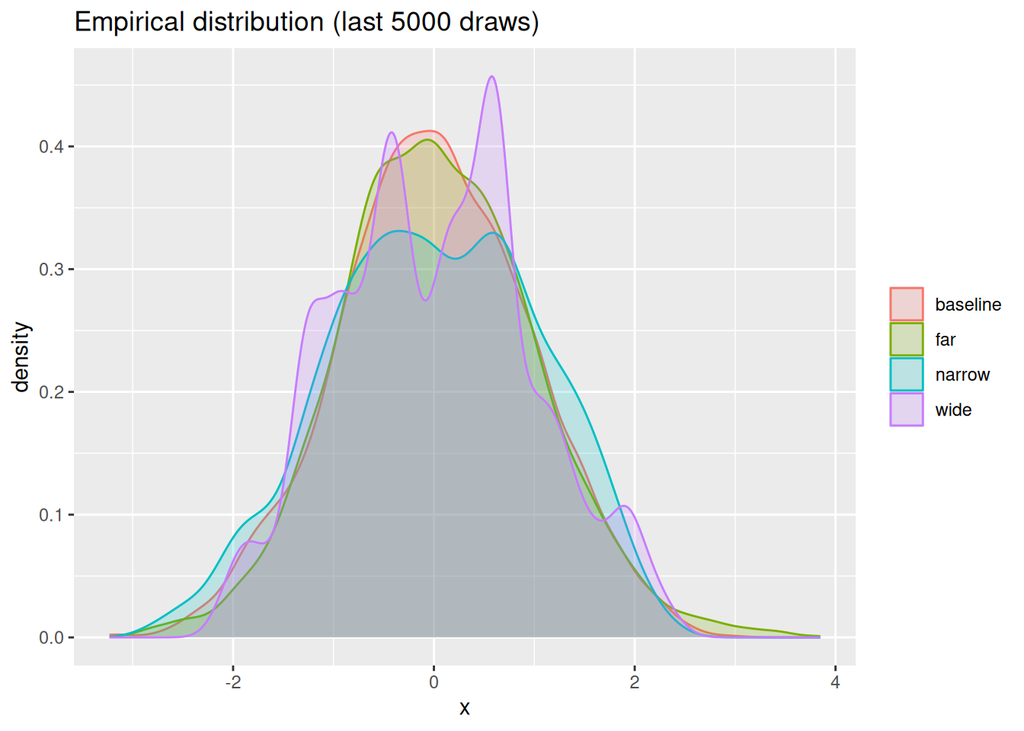

```r
# cummean
df_long %>%
  ggplot(aes(x = t, y = cummean, color = chain)) +
  geom_line() +
  labs(title = "Cumulative mean", x = "t", y = "cummean", color = NULL)

# cummean
df_long %>%
  filter(t>n_smpl-5000) %>%
  ggplot(aes(x = x, color = chain, fill = chain)) +
  geom_density(alpha = 0.2) +
  labs(title = "Empirical distribution (last 5000 draws)", x = "x", y = "density", color = NULL, fill = NULL)
```

## 3.2 統計量（未整理）

Gelman-Rubin, ESS, ACF ?

```r
n_rep <- 100
n_smpl_each <- 1000
lag_max <- 100
base_seed <- 1111

# 4つのチェーン設定を「定義のリスト」として持つ
chain_specs <- list(
  baseline = list(x_0 = 0, fun_proposal = function() runif(1, -1,  1)),
  wide     = list(x_0 = 0, fun_proposal = function() runif(1, -50, 50)),
  narrow   = list(x_0 = 0, fun_proposal = function() runif(1, -0.3, 0.3)),
  far      = list(x_0 = 10, fun_proposal = function() runif(1, -1,  1)))

# 1) 100回×4設定 を回して、x を縦持ちで集約
df_x <- map_dfr(1:n_rep, function(r) {
  set.seed(base_seed + r)

  imap_dfr(chain_specs, function(sp, chain_name) {
    smpl <- run_metropolis(
      n_smpl = n_smpl_each,
      x_0 = sp$x_0,
      fun_proposal = sp$fun_proposal
    )

    tibble(
      run = r,
      chain = chain_name,
      t = 1:length(smpl$x),
      x = smpl$x
    )
  })
})
```

```r
# ACF を tibble で返すヘルパー（lag=0..lag_max）
calc_acf_tbl <- function(x, lag_max = 100) {
  a <- stats::acf(x, lag.max = lag_max, plot = FALSE)
  tibble(
    lag = 0:lag_max,
    acf = as.numeric(a$acf)
  )
}
# 2) (run, chain) ごとに ACF(0..100) を計算して縦持ちにする
df_acf <- df_x %>%
  group_by(run, chain) %>%
  summarise(acf_tbl = list(calc_acf_tbl(x, lag_max = lag_max)), .groups = "drop") %>%
  unnest(acf_tbl)


# 3) run 間で集計（平均 + 5-95%区間）: 任意
df_acf_sum <- df_acf %>%
  group_by(chain, lag) %>%
  summarise(
    acf_mean = mean(acf),
    acf_p05  = quantile(acf, 0.05),
    acf_p95  = quantile(acf, 0.95),
    .groups = "drop"
  )

# 4) プロット：平均 + (5%,95%) リボン（同一図に重ね描き）
df_acf_sum %>%
  filter(lag >= 1) %>%   # lag=0 を除きたいなら
  ggplot(aes(x = lag, color = chain, fill = chain)) +
  geom_ribbon(aes(ymin = acf_p05, ymax = acf_p95), alpha = 0.15, color = NA) +
  geom_line(aes(y = acf_mean)) +
  labs(title = "ACF up to lag 100 (100 runs, n=1000 each)",
       x = "lag", y = "ACF", color = NULL, fill = NULL)
```

[output not shown]

```r
ess_geyer_ips <- function(x, lag_max = 2000) {
  x <- as.numeric(x)
  N <- length(x)
  if (N < 3) stop("Need at least 3 draws.")

  a <- stats::acf(x, lag.max = min(lag_max, N - 1), plot = FALSE)
  rho <- as.numeric(a$acf)[-1]  # drop lag 0

  M <- floor(length(rho) / 2)
  if (M == 0) return(list(ESS = N, tau = 1))

  gamma <- rho[2*(1:M) - 1] + rho[2*(1:M)]
  m_stop <- which(gamma <= 0)[1]
  if (!is.na(m_stop)) gamma <- gamma[1:(m_stop - 1)]

  tau <- 1 + 2 * sum(gamma, na.rm = TRUE)
  tau <- max(tau, 1)
  list(ESS = N / tau, tau = tau)
}

df_ess <- df_x %>%
  group_by(run, chain) %>%
  summarise(
    N = n(),
    tau = ess_geyer_ips(x, lag_max = 500)$tau,
    ESS = ess_geyer_ips(x, lag_max = 500)$ESS,
    .groups = "drop"
  )

# run間の集計（平均と区間）
df_ess_sum <- df_ess %>%
  group_by(chain) %>%
  summarise(
    ESS_mean = mean(ESS),
    ESS_p05  = quantile(ESS, 0.05),
    ESS_p95  = quantile(ESS, 0.95),
    tau_mean = mean(tau),
    .groups = "drop"
  )
```

```r
df_ess_sum
```

```
## # A tibble: 4 × 5
##   chain    ESS_mean ESS_p05 ESS_p95 tau_mean
##   <chr>       <dbl>   <dbl>   <dbl>    <dbl>
## 1 baseline     65.1   38.1     92.6     16.7
## 2 far          38.6   22.8     55.1     27.8
## 3 narrow       12.8    6.06    21.7     90.5
## 4 wide         26.5   11.9     42.8     44.7
```

```r
# Gelman-Rubin R-hat (PSRF) for scalar x
rhat_psrf <- function(draws_mat, split = TRUE) {
  # draws_mat: matrix (iter x chain)
  stopifnot(is.matrix(draws_mat))
  if (split) {
    n <- nrow(draws_mat)
    if (n %% 2 != 0) draws_mat <- draws_mat[-n, , drop = FALSE]  # 奇数なら最後を落とす
    n <- nrow(draws_mat)
    half <- n / 2
    # split chains: (iter/2) x (2*chain)
    draws_mat <- cbind(draws_mat[1:half, , drop = FALSE],
                       draws_mat[(half+1):n, , drop = FALSE])
  }

  n <- nrow(draws_mat)  # iterations per chain
  m <- ncol(draws_mat)  # number of chains
  if (n < 2 || m < 2) stop("Need at least 2 iterations and 2 chains for R-hat.")

  chain_means <- colMeans(draws_mat)
  chain_vars  <- apply(draws_mat, 2, var)

  W <- mean(chain_vars)
  B <- n * var(chain_means)  # between-chain variance * n

  var_plus <- (n - 1) / n * W + (1 / n) * B
  Rhat <- sqrt(var_plus / W)

  # 数値安定性（W=0など）への保険
  if (!is.finite(Rhat)) Rhat <- NA_real_
  Rhat
}

# Run multiple chains per setting (baseline/wide/narrow)
run_multi_chains <- function(n_iter, inits, fun_proposal, warmup = 0, seed0 = 1111) {
  # returns: matrix (post-warmup iter x n_chain)
  stopifnot(warmup < n_iter)
  n_chain <- length(inits)
  n_keep  <- n_iter - warmup

  draws_mat <- matrix(NA_real_, nrow = n_keep, ncol = n_chain)
  colnames(draws_mat) <- paste0("chain", seq_len(n_chain))

  for (j in seq_len(n_chain)) {
    set.seed(seed0 + j)
    smpl <- run_metropolis(
      n_smpl = n_iter,
      x_0 = inits[j],
      fun_proposal = fun_proposal
    )
    draws_mat[, j] <- smpl$x[(warmup + 1):n_iter]
  }
  draws_mat
}

# Settings: 3-4 chains with dispersed initials
n_iter  <- 1000
warmup  <- 500
inits   <- c(-10, 0, 10, 20)  # 3本なら c(-10, 0, 10) などに

specs_gr <- list(
  baseline = function() runif(1, -1,  1),
  wide     = function() runif(1, -50,  50),
  narrow   = function() runif(1, -0.3, 0.3)
)

# Run + compute R-hat per setting
res_gr <- imap(specs_gr, function(fp, nm) {
  draws <- run_multi_chains(
    n_iter = n_iter,
    inits = inits,
    fun_proposal = fp,
    warmup = warmup,
    seed0 = 1111 + 1000 * match(nm, names(specs_gr))
  )

  tibble(
    setting = nm,
    n_chain = length(inits),
    n_iter = n_iter,
    warmup = warmup,
    Rhat_split = rhat_psrf(draws, split = TRUE),
    Rhat_nosplit = rhat_psrf(draws, split = FALSE)
  )
})

df_rhat <- bind_rows(res_gr)
```

```r
df_rhat
```

```
## # A tibble: 3 × 6
##   setting  n_chain n_iter warmup Rhat_split Rhat_nosplit
##   <chr>      <int>  <dbl>  <dbl>      <dbl>        <dbl>
## 1 baseline       4   1000    500       1.03         1.02
## 2 wide           4   1000    500       1.11         1.03
## 3 narrow         4   1000    500       1.36         1.16
```